# Publication Figure 4

# Libraries

Standard Import

```r
library(tidyverse)
library(cowplot)
library(scales)
library(ggpubr)
```

Special

```r
library(caret)
library(plotROC)
library(tidymodels)
library(grid)
library(sjPlot)
```

# Paths

```r
bin_dir = '../bin/'
data_dir = '../data/'
results_dir = '../results/'
```

# Custom Scripts / Theme

```r
source(paste0(bin_dir, 'theme_settings.R'))
source (paste0(bin_dir, 'utilities.R'))
source(paste0(bin_dir, 'species_competition_functions.R'))
source(paste0(bin_dir, 'distmat_utils.R'))
source(paste0(bin_dir, 'analysis_metadata.R'))
date <- format(Sys.time(), "%d%m%y")
```

# Import Tables

Metadata

```r
samples.metadata <- read_tsv(paste0(data_dir, 'samples.metadata.tsv'))
microbe.taxonomy <- read_tsv(paste0(data_dir, 'microbe.taxonomy.tsv'))
microbe.metadata <- microbe.taxonomy %>%
  right_join(., read_tsv(paste0(data_dir, 'microbe.metadata.tsv')))
```

## Taxonomy

MetaPhlAn2 tables combine with taxonomy

```r
mp_species.long <- microbe.taxonomy %>%
  right_join(., read_tsv(paste0(data_dir, 'samples.mp_profiles.species.tsv')),
             by = 'species') %>%
  left_join(., samples.metadata, by = 'Name')
```

rCDI subset annotate with metadata

```r
mp_species.rcdi.long <-
  mp_species.long %>%
  filter(Study %in% c(rcdi.studies))
```

## SameStr Data

SameStr Case-Summary table

```r
samples.sstr_data <- read_tsv(paste0(data_dir, 'samples.sstr_data_wmetadata.tsv')) %>%
  left_join(., microbe.taxonomy, by = 'species')
```

## Case Summary

SameStr Case-Summary table

```r
sstr_cases <- read_tsv(paste0(data_dir, 'samples.case_summary.tsv')) %>%
  left_join(., microbe.taxonomy, by = 'species')
```

# Functions

```r
precision <- function(matrix) {
    tp <- matrix[2, 2]
    fp <- matrix[1, 2]
    return (tp / (tp + fp))
}
recall <- function(matrix) {
    tp <- matrix[2, 2]
    fn <- matrix[2, 1]
    return (tp / (tp + fn))
}
```

# Set Figure

```r
fig = paste0('Fig_4.')
```

# Identify Individuals

Identifying related sample pairs coming from the same individual (controls) or from related biological context (rCDI) based on the number and fraction of shared family, genera, species and strains.

## Format

Generate MetaPhlAn co-occurrence table, taxa counts

```r
cooccurrence <- mp_cooccurrence(mp_species.long)
taxa_counts <- cooccurrence$mp_taxa_counts
taxa_cooccurrence <- cooccurrence$mp_taxa_table.long
```

Merge with SameStr strain-level data

```r
sstr <-
  samples.sstr_data %>%

  group_by(Study.pair, Name.row, Name.col,
           Days_Since_FMT.row, Days_Since_FMT.col,
           Case_Name.pair, Case_Name.row, Case_Name.col, Same_Case.label,
           Related.label, Related.bool, Pair_Type) %>%
  summarize(.groups = 'drop',
            n.analyzed_strains = sum(overlap > min_overlap, na.rm = T),
            n.shared_strains.mvs = sum(distance.mvs > min_similarity & overlap > min_overlap, na.rm = T),
            n.shared_strains.cvs = sum(distance.cvs > min_similarity & overlap > min_overlap, na.rm = T)) %>%

  # tag successful fmt cases
  mutate(fmt_success = !Case_Name.pair %in% cases_failed) %>%
  mutate(Study.row = str_split_fixed(Name.row, pattern = '_', 2)[,1],
         Study.col = str_split_fixed(Name.col, pattern = '_', 2)[,1]) %>%
  mutate(Related.text = ifelse(Related.bool, 'Related', 'Unrelated')) %>%

  rowwise() %>%
  mutate(Sample_Pair = paste0(sort(c(Name.row, Name.col)), collapse = ',')) %>%
  ungroup() %>%
  left_join(., taxa_cooccurrence, by = 'Sample_Pair') %>%
  left_join(., taxa_counts, by = c('Name.row' = 'Sample')) %>%
  left_join(., taxa_counts, by = c('Name.row' = 'Sample'), suffix = c('.row','.col')) %>%

  mutate(n.not_shared_species = (n.species.row - n.shared_species) + (n.species.col - n.shared_species),
         n.not_shared_genus = (n.genus.row - n.shared_genus) + (n.genus.col - n.shared_genus),
         n.not_shared_family = (n.family.row - n.shared_family) + (n.family.col - n.shared_family),

         n.total_species = n.shared_species + n.not_shared_species,
         n.total_genus = n.shared_genus + n.not_shared_genus,
         n.total_family = n.shared_family + n.not_shared_family,

         f.shared_strains.mvs = replace_na(n.shared_strains.mvs / n.analyzed_strains, 0),
         f.shared_strains.cvs = replace_na(n.shared_strains.cvs / n.analyzed_strains, 0),
         f.shared_species = n.shared_species / n.total_species,
         f.shared_genus = n.shared_genus / n.total_genus,
         f.shared_family = n.shared_family / n.total_family)
```

Subset rCDI and Controls

```r
# filter only healthy controls
sstr.control <-
  sstr %>%
  filter(Study.row %in% control.studies &
         Study.col %in% control.studies)

sstr.rcdi <-
  sstr %>%
  filter(Study.row %in% rcdi.studies &
         Study.col %in% rcdi.studies)

sstr.louiss <-
  sstr %>%
  filter(Study.row == 'LOUISS',
         Study.col == 'LOUISS')
```

## Logistic Regression Model

### Train on Control

Model on train data of healthy controls

```r
set.seed(50)
# 60% train / 40% test
trainIndex <- caret::createDataPartition(sstr.control$Related.bool, p = .6,
                                  list = FALSE,
                                  times = 1)[,1]
train <- sstr.control[ trainIndex,]
test <- sstr.control[-trainIndex,]

fit.norm.strain.all <-
  glm(Related.bool ~ n.total_species +
        f.shared_strains.mvs + n.shared_strains.mvs +
        f.shared_species + n.shared_species +
        f.shared_genus + n.shared_genus +
        f.shared_family + n.shared_family,
      data = train, family = binomial(link = 'logit'))
```

```
glm.fit: algorithm did not convergeglm.fit: fitted probabilities numerically 0 or 1 occurred
```

```r
# normal models
fit.norm.strain <-
  glm(Related.bool ~ f.shared_strains.mvs + n.shared_strains.mvs + n.analyzed_strains,
      data = train, family = binomial(link = 'logit'))
```

```
glm.fit: algorithm did not convergeglm.fit: fitted probabilities numerically 0 or 1 occurred
```

```r
fit.norm.species <-
  glm(Related.bool ~ f.shared_species + n.shared_species + n.total_species,
      data = train, family = binomial(link = 'logit'))
fit.norm.genus <-
  glm(Related.bool ~ f.shared_genus + n.shared_genus + n.total_genus,
      data = train, family = binomial(link = 'logit'))
fit.norm.family <-
  glm(Related.bool ~ f.shared_family + n.shared_family + n.total_family,
      data = train, family = binomial(link = 'logit'))
```

### Test on Control

prediction on test data of healthy controls

```r
test$pred.norm.strain <- predict(fit.norm.strain, test, type = 'response')
test$pred.norm.strain.all <- predict(fit.norm.strain.all, test, type = 'response')
test$pred.norm.species <- predict(fit.norm.species, test, type = 'response')
test$pred.norm.genus <- predict(fit.norm.genus, test, type = 'response')
test$pred.norm.family <- predict(fit.norm.family, test, type = 'response')

test.long <-
  test %>%
  pivot_longer(names_to = 'model', values_to = 'M',
         cols = c('pred.norm.strain',
         # pred.norm.strain.all,
         'pred.norm.species',
         'pred.norm.genus',
         'pred.norm.family'))
```

#### Performance

PR with yardstick from tidymodels

```r
options(yardstick.event_first = FALSE)

c.d1 <-
  test.long %>%
  mutate(model = gsub(model, pattern = 'pred.norm.', replacement = ''),
         model = fct_relevel(model, 'family', 'genus', 'species', 'strain'))

c.d2 <-
  c.d1 %>%
  group_by(model) %>%
  pr_curve(data = ., truth = as.factor(Related.bool), M)

c.d3 <-
  c.d1 %>%
  group_by(model) %>%
  pr_auc(data = ., truth = as.factor(Related.bool), M, na_rm = T)
```

ROC with plotroc

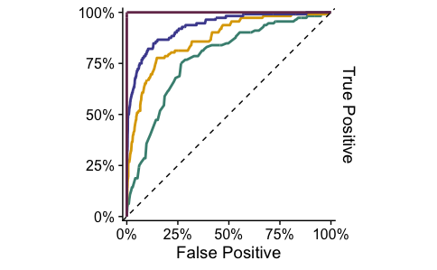

```r
x1 = .95
x2 = .77
yy = .17
p.expand <- rep(0.01, 2)

# auROC
control.auROC <-
  c.d1 %>%
  ggplot(aes(m = M, d = as.numeric(Related.bool), color = model)) +
  geom_roc(n.cuts = 0,
           labels = F) +
  theme_cowplot() +
  coord_fixed() +
  scale_color_manual(values = colors.discrete) +
  scale_x_continuous(labels = percent_format(), limits = c(0, 1), expand = p.expand) +
  scale_y_continuous(labels = percent_format(), limits = c(0, 1), expand = p.expand, sec.axis = dup_axis()) +
  geom_abline(slope = 1, linetype = 'dashed') +
  labs(x = 'False Positive', y = 'True Positive') +
  theme(legend.position = 'none',
        axis.line.y.right = element_blank(),
        axis.ticks.y.right = element_blank(),
        axis.text.y.right = element_blank(),
        axis.title.y.left = element_blank()
        # axis.text.x = element_blank(),
        # axis.ticks.x = element_blank(),
        # axis.line.x = element_blank()
        )

control.auROC.values <- calc_auc(control.auROC)$AUC
control.auPR.values <- c.d3$.estimate

control.auROC.table <-
  control.auROC +
  theme(legend.justification = c(0, 1), legend.position = c(.35, .38), legend.title = element_blank()) +
  annotate(geom = 'text', label = 'bold("auPR")', x = x1, y = .375, parse = T) +
  annotate(geom = 'text', label = 'bold("auROC")', x = x2, y = .375, parse = T) +
  annotate(geom = 'text', label = paste0(round(control.auROC.values, 3), collapse = '\n'),
           x = x2, y = yy, parse = F) +
  annotate(geom = 'text', label = paste0(round(control.auPR.values, 3), collapse = '\n'),
           x = x1, y = yy, parse = F)


# auPR (precision-recall plot)
control.auPR <-
  c.d2 %>%
  ggplot(aes(y = precision, x = recall, col = model)) +
  geom_line(size = 1) +
  coord_fixed() +
  theme_cowplot() +
  scale_color_manual(values = colors.discrete) +
  scale_x_continuous(labels = percent_format(), limits = c(0, 1), expand = p.expand) +
  scale_y_continuous(labels = percent_format(), limits = c(0, 1), expand = p.expand, sec.axis = dup_axis()) +
  labs(x = 'Recall', y = 'Precision') +
  geom_abline(intercept = 1, slope = -1, linetype = 'dashed') +
  theme(legend.position = 'none',
        axis.line.y.right = element_blank(),
        axis.ticks.y.right = element_blank(),
        axis.text.y.right = element_blank(),
        axis.title.y.left = element_blank())

control.auROC
```

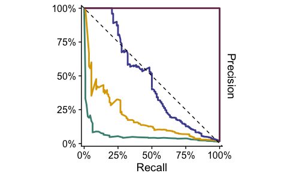

```r
control.auPR
```

#### Confusion Matrix

```r
# inspect false calls
sstr.control.confusion <-
  test %>%
  mutate(Predicted = pred.norm.strain > 8.713023e-08,
         TP = Predicted & Related.bool,
         FP = Predicted & !Related.bool,
         FN = !Predicted & Related.bool,
         TN = !Predicted & !Related.bool) %>%
  group_by(Pair_Type, Related.label, fmt_success) %>%
  summarize(TP = sum(TP, na.rm = T),
            FP = sum(FP, na.rm = T),
            FN = sum(FN, na.rm = T),
            TN = sum(TN, na.rm = T),
            .groups = 'drop') %>%
  mutate(Acc = (TP + TN) / (TP + TN + FP + FN))

sstr.control.confusion
```

| Pair_Type | Related.label | fmt_success | TP | FP | FN | TN | Acc |
| --- | --- | --- | --- | --- | --- | --- | --- |
| First-Control/First-Control | Distinct Subject | TRUE | 0 | 0 | 0 | 858 | 1 |
| First-Control/Later-Control | Distinct Subject | TRUE | 0 | 0 | 0 | 3560 | 1 |
| First-Control/Later-Control | Same Subject | TRUE | 46 | 0 | 0 | 0 | 1 |
| Later-Control/Later-Control | Distinct Subject | TRUE | 0 | 0 | 0 | 3590 | 1 |
| Later-Control/Later-Control | Same Subject | TRUE | 66 | 0 | 0 | 0 | 1 |

### Test on rCDI

Predict using control-trained model on FMT sample pairs, including donor/post-FMT, recipient/post-FMT.

```r
# prediction
sstr.rcdi$pred.norm.strain <- predict(fit.norm.strain, sstr.rcdi, type = 'response')
sstr.rcdi$pred.norm.strain.all <- predict(fit.norm.strain.all, sstr.rcdi, type = 'response')
sstr.rcdi$pred.norm.species <- predict(fit.norm.species, sstr.rcdi, type = 'response')
sstr.rcdi$pred.norm.genus <- predict(fit.norm.genus, sstr.rcdi, type = 'response')
sstr.rcdi$pred.norm.family <- predict(fit.norm.family, sstr.rcdi, type = 'response')

sstr.rcdi.long <-
  sstr.rcdi %>%
  pivot_longer(names_to = 'model', values_to = 'M',
         cols = c('pred.norm.strain',
         # pred.norm.strain.all,
         'pred.norm.species',
         'pred.norm.genus',
         'pred.norm.family'))
```

#### Performance

PR curve

```r
options(yardstick.event_first = FALSE)

r.d1 <-
  sstr.rcdi.long %>%
  mutate(model = gsub(model, pattern = 'pred.norm.', replacement = ''),
         model = fct_relevel(model, 'family', 'genus', 'species', 'strain'))

r.d2 <-
  r.d1 %>%
  ungroup() %>%
  group_by(model) %>%
  pr_curve(data = ., truth = as.factor(Related.bool), M)

r.d3 <-
  r.d1 %>%
  group_by(model) %>%
  pr_auc(data = ., truth = as.factor(Related.bool), M, na_rm = T)
```

ROC

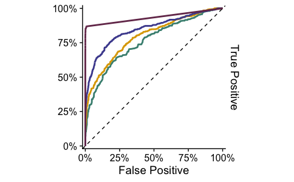

```r
x1 = .95
x2 = .77
yy = .17
p.expand <- rep(0.01, 2)

# auROC
rcdi.auROC <-
  r.d1 %>%
  ggplot(aes(m = M, d = as.numeric(Related.bool), color = model)) +
  geom_roc(n.cuts = 0, labels = F) +
  theme_cowplot() +
  coord_fixed() +
  scale_color_manual(values = colors.discrete) +
  scale_x_continuous(labels = percent_format(), limits = c(0, 1), expand = p.expand) +
  scale_y_continuous(labels = percent_format(), limits = c(0, 1), expand = p.expand, sec.axis = dup_axis()) +
  geom_abline(slope = 1, linetype = 'dashed') +
  labs(x = 'False Positive', y = 'True Positive') +
  theme(aspect.ratio = 1,
        legend.position = 'none',
        axis.line.y.right = element_blank(),
        axis.ticks.y.right = element_blank(),
        axis.text.y.right = element_blank(),
        axis.title.y.left = element_blank()
        )

rcdi.auROC.values <- calc_auc(rcdi.auROC)$AUC
rcdi.auPR.values <- r.d3$.estimate

# auPR (precision-recall plot)
rcdi.auPR <-
  r.d2 %>%
  ggplot(aes(y = precision, x = recall, col = model)) +
  geom_line(size = 1) +
  coord_fixed() +
  theme_cowplot() +
  scale_color_manual(values = colors.discrete) +
  scale_x_continuous(labels = percent_format(), limits = c(0, 1), expand = p.expand) +
  scale_y_continuous(labels = percent_format(), limits = c(0, 1), expand = p.expand, sec.axis = dup_axis()) +
  labs(x = 'Recall', y = 'Precision') +
  geom_abline(intercept = 1, slope = -1, linetype = 'dashed') +
  theme(aspect.ratio = 1,
        legend.position = 'none',
        axis.line.y.right = element_blank(),
        axis.ticks.y.right = element_blank(),
        axis.text.y.right = element_blank(),
        axis.title.y.left = element_blank()
        )

rcdi.auROC
```

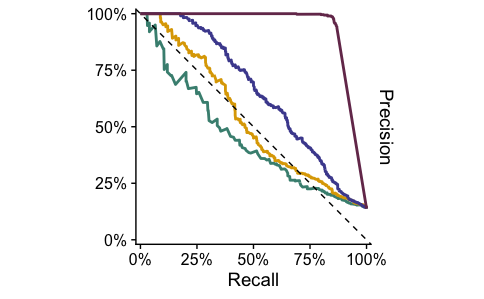

```r
rcdi.auPR
```

#### Confusion Matrix

```r
# inspect false calls
sstr.rcdi.confusion <-
  sstr.rcdi %>%
  mutate(Predicted = pred.norm.strain > 0.001774427,
         TP = Predicted & Related.bool,
         FP = Predicted & !Related.bool,
         FN = !Predicted & Related.bool,
         TN = !Predicted & !Related.bool) %>%
  group_by(Pair_Type, Related.label, fmt_success) %>%
  summarize(TP = sum(TP, na.rm = T),
            FP = sum(FP, na.rm = T),
            FN = sum(FN, na.rm = T),
            TN = sum(TN, na.rm = T),
            .groups = 'drop') %>%
  mutate(Acc = (TP + TN) / (TP + TN + FP + FN))

sstr.rcdi.confusion
```

| Pair_Type | Related.label | fmt_success | TP | FP | FN | TN | Acc |
| --- | --- | --- | --- | --- | --- | --- | --- |
| Donor/Donor | Distinct Subject | TRUE | 0 | 0 | 0 | 101 | 1.0000000 |
| Donor/Donor | Same Donor | TRUE | 4 | 0 | 0 | 0 | 1.0000000 |
| Donor/Post-FMT | Distinct Subject | TRUE | 0 | 0 | 0 | 664 | 1.0000000 |
| Donor/Post-FMT | Same Case | FALSE | 10 | 0 | 1 | 0 | 0.9090909 |
| Donor/Post-FMT | Same Case | TRUE | 36 | 0 | 5 | 0 | 0.8780488 |
| Donor/Post-FMT | Same Donor | TRUE | 58 | 0 | 6 | 0 | 0.9062500 |
| Post-FMT/Post-FMT | Distinct Subject | TRUE | 0 | 0 | 0 | 911 | 1.0000000 |
| Post-FMT/Post-FMT | Same Case | FALSE | 6 | 0 | 0 | 0 | 1.0000000 |
| Post-FMT/Post-FMT | Same Case | TRUE | 37 | 0 | 2 | 0 | 0.9487179 |
| Post-FMT/Post-FMT | Same Donor | TRUE | 292 | 0 | 78 | 0 | 0.7891892 |

[output cut: 6 more lines]

Write to File

```r
sstr.rcdi.confusion %>%
  write_tsv(., paste0(results_dir, fig, 'ConfusionMatrix.rCDI.tsv'))
```

#### Scatter Plot

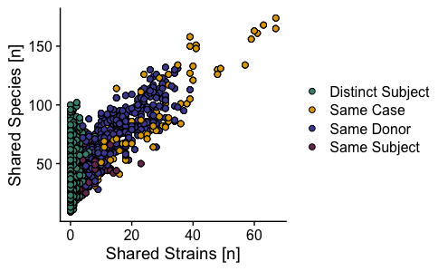

```r
r.d1 %>%
  ggplot(aes(n.shared_strains.mvs, n.shared_species)) +
  geom_point(aes(fill = Related.label), size = 2, shape = 21) +
  scale_fill_manual(values = colors.discrete) +
  theme_cowplot() +
  theme(legend.title = element_blank()) +
  labs(x = 'Shared Strains [n]',
       y = 'Shared Species [n]')
```

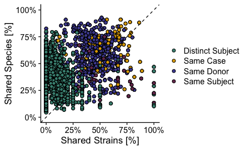

```r
r.d1 %>%
  ggplot(aes(f.shared_strains.mvs, f.shared_species)) +
  geom_point(aes(fill = Related.label), size = 2, shape = 21) +
  geom_abline(slope = 1, intercept = 0, linetype = 'dashed') +

  scale_x_continuous(labels = percent_format(), limits = c(0, 1)) +
  scale_y_continuous(labels = percent_format(), limits = c(0, 1)) +
  theme_cowplot() +
  theme(aspect.ratio = 1, legend.title = element_blank()) +
  scale_fill_manual(values = colors.discrete) +
  labs(x = 'Shared Strains [%]',
       y = 'Shared Species [%]')
```

### Model Summary

Exporting Table

```r
model_comparison <-
  tibble(model = c('family', 'genus', 'species', 'strain'),
         control.auROC = control.auROC.values,
         control.auPR = control.auPR.values,
         rcdi.auROC = rcdi.auROC.values,
         rcdi.auPR = rcdi.auPR.values,
         )

output_name = 'RelatedSubject.ModelPerformance'
sjPlot::tab_df(model_comparison, digits = 4,
               alternate.rows = F,
               file = paste0(results_dir, fig, output_name, '.doc'),
               title = 'Logistic Regression Model Performance')
```

Exporting Plots

```r
ww = 3.25
hh = 3
# legend
legend = cowplot::get_legend(rcdi.auROC + theme(legend.position = 'left',
                   legend.title = element_blank()))
output_name = 'RelatedSubject'
ggsave(legend, device = 'pdf',
       filename = paste0(results_dir, fig, output_name, '.Legend.pdf'),
       dpi = 300, width = 1, height = .9)

# control
output_name = 'RelatedSubject.Control'
ggsave(control.auROC, device = 'pdf',
       filename = paste0(results_dir, fig, output_name, '.auROC.pdf'),
       dpi = 300, width = ww, height = hh)

ggsave(control.auPR, device = 'pdf',
       filename = paste0(results_dir, fig, output_name, '.auPR.pdf'),
       dpi = 300, width = ww, height = hh)

# rcdi
output_name = 'RelatedSubject.rCDI'
ggsave(rcdi.auROC, device = 'pdf',
       filename = paste0(results_dir, fig, output_name, '.auROC.pdf'),
       dpi = 300, width = ww, height = hh)

ggsave(rcdi.auPR, device = 'pdf',
       filename = paste0(results_dir, fig, output_name, '.auPR.pdf'),
       dpi = 300, width = ww, height = hh)
```

# Strain-level Source (Control)

Strain-level plot of per-Case second time point rel. abund. by source

## Format

```r
sstr_cases.control.long <-
  sstr_cases %>%

  filter(Study_Type == 'Control') %>%

  tag_species_competition(.) %>%

  mutate(n = 1) %>%
  mutate(source = ifelse(grepl(species, pattern = 'unclassified'),  'Unclassified', source)) %>%

    mutate(source = case_when(
    analysis_level == 'species' & source == 'self' ~ 'Initial Sample Sp.',
    analysis_level == 'species' & source == 'unique' ~ 'New Sp.',
    T ~ source
  )) %>%

  group_by(Study_Type, Case_Name, source, Days_Since_FMT.post, fmt_success.label) %>%
  summarize(n = sum(n, na.rm = T),
            rel_abund = sum(rel_abund.post, na.rm = T) / 100,
            .groups = 'drop') %>%
  group_by(Case_Name, Days_Since_FMT.post) %>%
  mutate(f = n / sum(n, na.rm = T)) %>%
  ungroup() %>%
  select(-n) %>%

  group_by(Case_Name) %>%
  mutate(source = case_when(source == 'Unclassified' ~ 'Unclassified Sp.',
                  source == 'same_species' ~ 'Same Sp.',
                  source == 'unique' ~ 'New',
                  source == 'self' ~ 'Initial Sample',
                  T ~ source)) %>%

  pivot_wider(names_from = 'source',
               values_from = c('rel_abund','f'), names_sep = '___') %>%
  mutate_at(.vars = vars(contains('___')),
            .funs = funs(replace_na(., 0))) %>%
  pivot_longer(cols = contains("___"),
               names_to = c("metric", "source"),
               names_sep = '___', values_drop_na = F)
```

Statistics Retained (strain-level) from previous time point: 73.1 +- 18.3%

```r
sstr_cases.control.long  %>%
  filter(metric == 'rel_abund') %>%
  filter(Days_Since_FMT.post <= 373) %>% # ~ same time range as last rcdi
  group_by(Study_Type, Case_Name) %>%
  filter(dense_rank(Days_Since_FMT.post) == max(dense_rank(Days_Since_FMT.post))) %>%
  ungroup() %>%
  group_by(Study_Type, source) %>%
  summarize(rel_abund.mean = mean(value, na.rm = T),
            rel_abund.sd = sd(value, na.rm = T),
            .groups = 'drop')
```

| Study_Type | source | rel_abund.mean | rel_abund.sd |
| --- | --- | --- | --- |
| Control | Initial Sample | 0.73137575 | 0.18299947 |
| Control | Initial Sample Sp. | 0.10082839 | 0.08051853 |
| Control | New | 0.06447463 | 0.09700380 |
| Control | New Sp. | 0.02913897 | 0.03738659 |
| Control | Unclassified Sp. | 0.07353421 | 0.05180298 |

```r
sstr_cases.control.long  %>%
  filter(metric == 'f') %>%
  filter(Days_Since_FMT.post <= 373) %>% # ~ same time range as last rcdi
  group_by(Study_Type, Case_Name) %>%
  filter(dense_rank(Days_Since_FMT.post) == max(dense_rank(Days_Since_FMT.post))) %>%
  ungroup() %>%
  group_by(Study_Type, source) %>%
  summarize(fraction.mean = mean(value, na.rm = T),
            fraction.sd = sd(value, na.rm = T),
            .groups = 'drop')
```

| Study_Type | source | fraction.mean | fraction.sd |
| --- | --- | --- | --- |
| Control | Initial Sample | 0.22552184 | 0.06272234 |
| Control | Initial Sample Sp. | 0.30701993 | 0.06957897 |
| Control | New | 0.04863054 | 0.03383814 |
| Control | New Sp. | 0.28939882 | 0.09479845 |
| Control | Unclassified Sp. | 0.12942887 | 0.03264969 |

## Bar Chart, per Case

Control - Bar charts showing second time point rel. abund. of sets of co-occurring strains in first and second time points of controls.

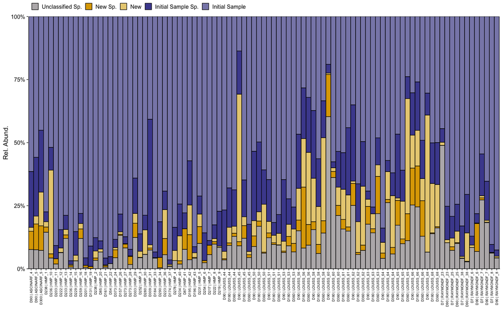

```r
strain_order <- c('Initial Sample', 'Initial Sample Sp.', 'New', 'New Sp.', 'Same Sp.')
strain_colors <- c(colors.discrete[c(8,3, 7,2, 10,5)])
use_vars = list(strain_order, strain_colors)

plot.control <-
  sstr_cases.control.long  %>%
  filter(metric == 'rel_abund') %>%
  filter(Days_Since_FMT.post <= 373) %>% # ~ same time range as last rcdi
  ungroup() %>%
  mutate(ordering = as.numeric(as.factor(Case_Name)) + (Days_Since_FMT.post/1000)) %>%
  ggplot(aes(
    fct_reorder(paste0('D', Days_Since_FMT.post, ' | ', str_remove(Case_Name, pattern = 'Case_')), ordering),
    y = value,
    fill = fct_relevel(source, use_vars[[1]]))) +

  geom_bar(stat = 'identity', position = position_fill(), width = 1, col = 'black') +
  theme_cowplot() +
  scale_y_continuous(labels = percent_format(),
                     breaks = c(1, .75, .5, .25, 0),
                     expand = c(0,0)) +
  scale_fill_manual(values = strain_colors,

                    guide = guide_legend(reverse = TRUE)) +
  labs(y = 'Rel. Abund.') +
  theme(
        axis.title.x = element_blank(),
        axis.line.y = element_blank(),
        axis.text.x = element_text(angle = 90, hjust = 1, vjust = 0.5, size = 7.5),
        legend.title=element_blank(),
        legend.position = 'top')
plot.control
```

Exporting plots

```r
output_name = 'PostSource.Cases.Control.Strain'
ggsave(plot.control + theme(legend.position = 'none'),
       device = 'pdf', dpi = 300, width = 25, height = 3.5,
       filename = paste0(results_dir, fig, output_name, '.Plot.pdf'))
```

## Area Chart, Across Cases

Control - Area chart showing second time point rel. abund. of sets of co-occurring strains in first and second time points of controls based on glm 2nd binomial model across control cases

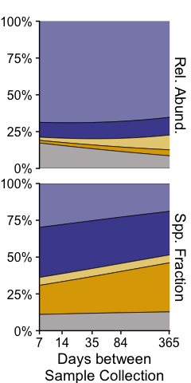

```r
strain_order <- c('Initial Sample', 'Initial Sample Sp.', 'New', 'New Sp.', 'Same Sp.')
strain_colors <- c(colors.discrete[c(8,3, 7,2, 10,5)])
use_vars = list(strain_order, strain_colors)

pseudo = 1e-6
plot <-

  sstr_cases.control.long  %>%
  filter(Days_Since_FMT.post <= 373) %>% # ~ same time range as last rcdi

  ggplot(aes(x = Days_Since_FMT.post,
             y = value,
             fill = fct_relevel(source, use_vars[[1]]))
         ) +

  stat_smooth(geom = 'area',
              method = 'glm', colour = 'black', size = 0.25,
              position = 'fill',
              method.args=list(family='binomial')
              ) +

   facet_grid(scales = 'free_x', space = 'free_x',
   cols = vars(''),
   rows = vars(ifelse(grepl(metric, pattern = '^f'),
                                'Spp. Fraction',
                                'Rel. Abund.'))) +
  theme_cowplot() +
  scale_y_continuous(labels = percent_format(),
                     breaks = c(1, .75, .5, .25, 0),
                     expand = c(0,0),
                     ) +
  scale_x_continuous(trans = pseudo_log_trans(0.5, 10),
                     breaks = c(pseudo, 7, 14, 35, 84, 365),
                     expand = c(0,0)) +
  scale_fill_manual(values = use_vars[[2]],
                    guide = guide_legend(reverse = TRUE)) +
  # labs(x = 'Days Since\nInitial Sampling') +
  labs(x = 'Days between\nSample Collection') +
  theme(axis.title.y = element_blank(),
        plot.margin = unit(c(0, 0, 0, 0), "cm"),
        strip.background = element_blank(),
        strip.text = element_text(size = 14),
        panel.spacing.y = unit(.5, "cm"),
        panel.spacing.x = unit(.35, "cm"),
        legend.title=element_blank(),
        legend.margin=ggplot2::margin(l = 0.1, unit='cm'))


plot + theme(legend.position = 'none')
```

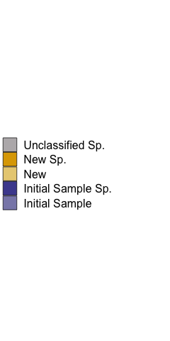

```r
legend <- cowplot::get_legend(plot)

grid.newpage()
grid.draw(legend)
```

Histogram of available samples for modelling

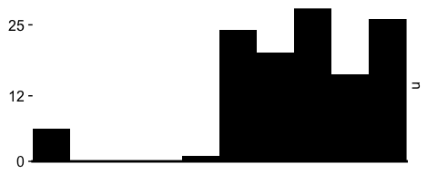

```r
plot.histogram <-
  sstr_cases.control.long %>%
  filter(metric == 'f') %>%
  group_by(Study_Type, Case_Name, Days_Since_FMT.post) %>%
  summarize(value = sum(value, na.rm = T)) %>%
  ggplot(aes(Days_Since_FMT.post)) +
  geom_histogram(fill = 'black', bins = 10) +
  facet_grid(scales = 'free_x', space = 'free_x',
   cols = vars(fct_relevel(Study_Type, 'rCDI', 'Control')),
   rows = vars('n')) +
  scale_x_continuous(trans = pseudo_log_trans(0.5, 10),
                     breaks = c(pseudo, 7, 14, 30, 90, 365),
                     expand = c(0,0)) +
  scale_y_continuous(breaks = c(0, 12, 25),
                     expand = c(0,0),
                     ) +
  theme_cowplot() +
  theme(strip.background = element_blank(),
        strip.text.x = element_blank(),
        axis.title = element_blank(),
        axis.line.x = element_line(size = 1),
        axis.line.y = element_blank(),
        axis.text.x = element_blank(),
        axis.ticks.x = element_blank(),
        legend.title=element_blank())

plot.histogram
```

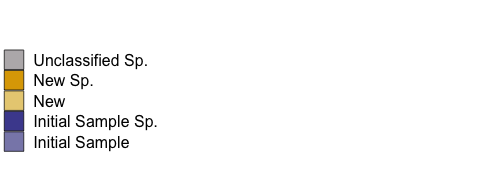

```r
legend = cowplot::get_legend(plot)
grid.newpage()
grid.draw(legend)
```

Exporting plot

```r
output_name = 'PostSource.AcrossCases.Control.Strain'

ggsave(plot + theme(legend.position = 'none'),
       device = 'pdf', dpi = 300, width = 3, height = 5,
       filename = paste0(results_dir, fig, output_name, '.Plot.pdf'))
ggsave(plot.histogram + theme(legend.position = 'none'),
       device = 'pdf', dpi = 300, width = 3, height = .6,
       filename = paste0(results_dir, fig, output_name, '.Histogram','.Plot.pdf'))
ggsave(legend,
       device = 'pdf', dpi = 300, width = 5, height = 2,
       filename = paste0(results_dir, fig, output_name, '.Legend.pdf'))
```

## Strain-level Resolution

Format

```r
resolution <-
  sstr_cases %>%

  filter(Study_Type == 'Control') %>%

  tag_species_competition(.) %>%

  mutate(n = 1) %>%
  mutate(source = ifelse(grepl(species, pattern = 'unclassified'),  'Unclassified', source)) %>%

    mutate(source = case_when(
    analysis_level == 'species' & source == 'self' ~ 'Initial Sample Sp.',
    analysis_level == 'species' & source == 'unique' ~ 'New Sp.',
    T ~ source
  )) %>%

  group_by(Study_Type, Case_Name, source, Days_Since_FMT.post, fmt_success.label) %>%
  summarize(n = sum(n, na.rm = T),
            rel_abund = sum(rel_abund.post, na.rm = T) / 100,
            .groups = 'drop') %>%
  group_by(Case_Name, Days_Since_FMT.post) %>%
  mutate(f = n / sum(n, na.rm = T)) %>%
  ungroup() %>%
  select(-n) %>%

  group_by(Case_Name) %>%
  mutate(source = case_when(source == 'Unclassified' ~ 'Unclassified Sp.',
                  source == 'same_species' ~ 'Same Sp.',
                  source == 'unique' ~ 'New',
                  source == 'self' ~ 'Initial Sample',
                  T ~ source)) %>%

  pivot_wider(names_from = 'source',
               values_from = c('rel_abund','f'), names_sep = '___') %>%
  mutate_at(.vars = vars(contains('___')),
            .funs = funs(replace_na(., 0))) %>%
  pivot_longer(cols = contains("___"),
               names_to = c("metric", "source"),
               names_sep = '___', values_drop_na = F) %>%
  mutate(resolution = case_when(
    grepl(source, pattern = 'Sp.') ~ 'Species',
    T ~ 'Strain'
  )) %>%
  mutate(metric = case_when(
    metric == 'rel_abund' ~ 'Rel.\nAbund.',
    metric == 'f' ~ 'Spp.\nFraction',
    T ~ metric
  )) %>%
  group_by(Case_Name, Days_Since_FMT.post, metric, resolution) %>%
  summarize(value = sum(value, na.rm = T), .groups = 'drop')
```

Relative abundance and fraction of species, on average, for which we obtained strain-level resolution

```r
resolution %>%
  filter(resolution == 'Strain') %>%
  group_by(metric) %>%
  summarize(value.mean = mean(value, na.rm = T),
            value.sd = sd(value, na.rm = T), .groups = 'drop')
```

| metric | value.mean | value.sd |
| --- | --- | --- |
| Rel.\nAbund. | 0.7144395 | 0.15960075 |
| Spp.\nFraction | 0.2624353 | 0.06769837 |

Boxplots

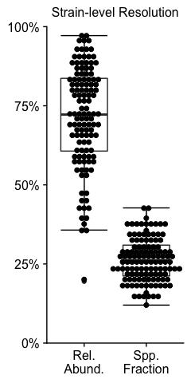

```r
plot.resolution <-
  resolution %>%
  filter(resolution == 'Strain') %>%

  ggplot(aes(metric, value)) +
  stat_boxplot(geom = 'errorbar') +
  geom_boxplot(show.legend = F) +
  geom_dotplot(aes(fill = NULL), binaxis = "y",
               stackdir = "center", binpositions="all", binwidth = 0.015) +

  scale_y_continuous(labels = percent_format(),
                     breaks = seq(0, 1, .25),
                     expand = c(0,0),
                     limits = c(0, 1)
                     ) +
  theme_cowplot() +
  theme(legend.position = 'none', # c(.6, .65),
        legend.title = element_blank(),
        plot.subtitle = element_text(hjust = 0.5),
        axis.title = element_blank(),
        ) +
  labs(subtitle = 'Strain-level Resolution')
plot.resolution
```

Exporting plot

```r
output_name = 'PostSource.Control.Strain'

ggsave(plot.resolution,
       device = 'pdf', dpi = 300, width = 2.25, height = 3.75,
       filename = paste0(results_dir, 'Fig_3.', output_name, '.ResolutionPlot.pdf'))
```

# Shared Strains (rCDI)

## Family Related

```r
plot <-
  sstr.rcdi %>%
  filter(Pair_Type == 'Pre-FMT/Donor') %>%
  mutate(tag.facet = case_when(
    Related.label == 'Same Subject' ~ 'Same Individual',
    Related.label == 'Same Donor' & Pair_Type == 'Donor/Donor' ~ 'Same Individual',
    Related.label == 'Same Case' & Pair_Type != 'Donor/Post-FMT' ~ 'Same Individual',
    Related.label == 'Same Donor' & Pair_Type == 'Post-FMT/Post-FMT' ~ 'Treatment-related',
    Related.label %in% c('Same Donor', 'Same Case') & Pair_Type == 'Donor/Post-FMT' ~ 'Treatment-related',
    T ~ Related.label),
    tag.x =
           case_when(Related.label == 'Distinct Subject' ~ 'Unrelated\nSample Pair',
                     T ~ gsub(Pair_Type, pattern = '/', replacement= '\n'))) %>%

  mutate(tag.x = case_when(Pair_Type == 'Pre-FMT/Donor' & Study.pair == 'FRICKE' ~
                             'Family-related\nPre-FMT/Donor',
                           T ~ tag.x),
         tag.x = case_when(Related.label == 'Same Donor' ~ paste0(gsub(tag.x, pattern = '\n', replacement ='*\n'), '*'),
    T ~ tag.x),
 tag.x = fct_relevel(as.factor(gsub(tag.x, pattern = '-FMT', replacement = '')),
                     'Pre\nPost', 'Donor\nPost')) %>%
  ggplot(aes(tag.x, n.shared_strains.mvs, fill = tag.facet)) +
  stat_boxplot(geom = 'errorbar') +
  geom_boxplot() +
  stat_compare_means(method = 'wilcox', label.x.npc = 0.5,
                     exact = F, label = 'p.signif'
                     ) +

  facet_grid(cols = vars(tag.facet),
             scales = 'free', space = 'free_x') +
  scale_fill_manual(values = c('black', 'grey75','white')) +
  theme_cowplot() +
  guides(color = guide_legend(ncol = 1),
         linetype = guide_legend(ncol = 1)) +
  theme(legend.title=element_blank(),
        axis.title.x = element_blank(),
        panel.margin.y = unit(.5, "lines"),
        panel.background = element_blank(),
        strip.background = element_blank(),
        strip.text = element_blank(),
        axis.text = element_text(size = 9),
        axis.title = element_text(size = 11),
        axis.text.x = element_text(hjust = 0.5),
        text = element_text(colour = 'black'),
        ) +
  labs(y = 'Strains Shared between Samples')
```

```
Unknown levels in `f`: Pre
Post, Donor
PostIgnoring unknown parameters: exact`panel.margin` is deprecated. Please use `panel.spacing` property instead`panel.margin` is deprecated. Please use `panel.spacing` property instead
```

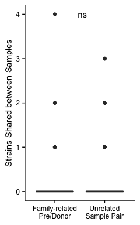

```r
plot + theme(legend.position = 'none')
```

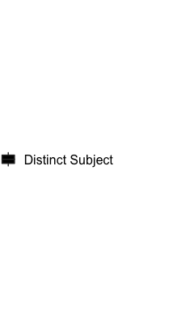

```r
legend = cowplot::get_legend(plot)
grid.newpage()
grid.draw(legend)
```

## FMT Related

```r
plot <-
  sstr.rcdi %>%

  mutate(tag.facet = case_when(
    Related.label == 'Same Subject' ~ 'Same Individual',
    Related.label == 'Same Donor' & Pair_Type == 'Donor/Donor' ~ 'Same Individual',
    Related.label == 'Same Case' & Pair_Type != 'Donor/Post-FMT' ~ 'Same Individual',
    Related.label == 'Same Donor' & Pair_Type == 'Post-FMT/Post-FMT' ~ 'Same Donor',
    Related.label %in% c('Same Donor', 'Same Case') & Pair_Type == 'Donor/Post-FMT' ~ 'Same Donor',
    Related.label == 'Distinct Subject' ~ 'Different Individuals',
    T ~ 'Unknown'),
    tag.x = gsub(Pair_Type, pattern = '/', replacement = '\n'),
    tag.x = gsub(tag.x, pattern = '-FMT', replacement = ''),
    tag.x = ifelse(tag.x == 'Pre\nDonor', 'Donor\nPre', tag.x),
    tag.x = fct_relevel(tag.x,
                     'Pre\nPre', 'Pre\nPost', 'Post\nPost',
                     'Donor\nDonor', 'Donor\nPre', 'Donor\nPost')) %>%
  mutate(tag.facet = fct_relevel(tag.facet, 'Same Individual', 'Same Donor')) %>%
  mutate(tag.f = ifelse(grepl(tag.x, pattern = 'Donor'),  'Donor-Related', 'Patient-Related'),
         tag.f = fct_relevel(tag.f, 'Patient-Related')) %>%
  filter(!(tag.facet == 'Different Individuals' & tag.x %in% c('Pre\nPost', 'Donor\nPre', 'Donor\nPost'))) %>%

  ggplot(aes(tag.x, n.shared_strains.mvs, fill = tag.facet)) +
  stat_boxplot(geom = 'errorbar') +
  geom_boxplot() +

  facet_grid(cols = vars(tag.facet),
            scales = 'free', space = 'free_x') +
  scale_fill_manual(values = c('white', 'grey75','black')) +
  theme_cowplot() +
  guides(color = guide_legend(ncol = 1),
         linetype = guide_legend(ncol = 1)) +
  theme(legend.title=element_blank(),
        axis.title.x = element_blank(),
        panel.margin.y = unit(.5, "lines"),
        panel.background = element_blank(),
        strip.background = element_blank(),
        strip.text = element_blank(),
        axis.text = element_text(size = 9),
        axis.title = element_text(size = 11),
        axis.text.x = element_text(hjust = 0.5),
        text = element_text(colour = 'black'),
        ) +
  labs(y = 'Strains Shared between Samples')
```

```
`panel.margin` is deprecated. Please use `panel.spacing` property instead`panel.margin` is deprecated. Please use `panel.spacing` property instead
```

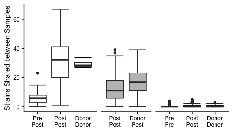

```r
plot + theme(legend.position = 'none')
```

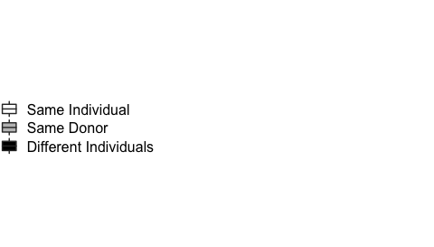

```r
legend = cowplot::get_legend(plot)
grid.newpage()
grid.draw(legend)
```

Exporting plot

```r
output_name = 'SharedStrains.rCDI'

ggsave(plot + theme(legend.position = 'none'),
       device = 'pdf', dpi = 300, width = 4.75, height = 3.05,
       filename = paste0(results_dir, fig, output_name, '.Plot.pdf'))
ggsave(legend,
       device = 'pdf', dpi = 300, width = 2, height = 1,
       filename = paste0(results_dir, fig, output_name, '.Legend.pdf'))
```

Statistics

```r
output_name = 'SharedStrains.rCDI'
sstr.rcdi %>%
  mutate(fmt_success.label = ifelse(fmt_success, 'Resolved', 'Failed')) %>%
  filter(Same_Case.label == 'Same Case') %>%
  select(Study.pair, Case_Name.pair, Pair_Type, fmt_success.label, starts_with('n.shared'), starts_with('Days_Since_FMT')) %>%
  filter(Pair_Type %in% c('Pre-FMT/Post-FMT', 'Donor/Post-FMT')) %>%
  rowwise() %>%
  mutate(Days_Since_FMT = max(c(Days_Since_FMT.row, Days_Since_FMT.col))) %>%
  ungroup() %>%
  group_by(Case_Name.pair) %>%
  filter(dense_rank(Days_Since_FMT) == max(dense_rank(Days_Since_FMT))) %>%
  ungroup() %>%
  select(-Days_Since_FMT.row, -Days_Since_FMT.col, -n.shared_strains.cvs, -n.shared_genus, -n.shared_family) %>%
  pivot_wider(names_from = 'Pair_Type', values_from = starts_with('n.shared'),
              id_cols = c('Days_Since_FMT', 'Study.pair', 'Case_Name.pair', 'fmt_success.label')) %>%
  select(Study.pair, Case_Name.pair, fmt_success.label, Days_Since_FMT, starts_with('n.shared_strains'), starts_with('n.shared_species')) %>%
  write_tsv(., paste0(results_dir, fig, output_name, '.Counts.tsv'))
```

# Labelling Control

## Format

```r
library(tidygraph)
library(ggraph)
```

```r
sstr_cooccurrence <- read_tsv(file = paste0(data_dir, 'samples.sstr_cooccurrence.tsv'))
```

## Set Figure

```r
fig = paste0('Suppl.Fig_6.')
```

```r
get_matrix <- function(data, selection, min_strain=3) {

  sstr_select <-
  data %>%
  filter(row %in% selection,
         col %in% selection)

  sstr_matrix <-
  bind_rows(sstr_select,
            sstr_select %>% rename(row = col, col = row)) %>%
  pivot_wider(names_from = col,
              values_from = n.shared_strain,
              values_fill = list(n.shared_strain = 0)) %>%
  column_to_rownames('row')

  idx <- intersect(rownames(sstr_matrix), colnames(sstr_matrix))
  sstr_matrix <- sstr_matrix[idx, idx]
  sstr_matrix[as.matrix(sstr_matrix) <= min_strain] <- 0

  return(sstr_matrix)
}

get_graph <- function(sstr_matrix) {
  sstr_graph <-
    as_tbl_graph(as.matrix(sstr_matrix), directed = F) %>%
    activate(nodes) %>%
    left_join(., samples.metadata, by = c('name' = 'Name'))
  return(sstr_graph)
}

generate_graph <- function(data, selection, min_strain=3) {
  return(get_graph(get_matrix(data, selection, min_strain=3)))
}
```

## LOUISS

LOUISS Case 64 / 66 last time point mislabelling

```r
selection <-
  samples.metadata %>%
  filter(Case_Name %in% c('LOUISS_Case_64', 'LOUISS_Case_66')) %>%
  pull(Name)

misl1 <-
  get_matrix(sstr_cooccurrence, selection, 0) %>%
  rownames_to_column('row') %>%
  pivot_longer(names_to = 'col', values_to = 'shared',
               cols = ends_with('.pair')) %>%
  filter(row != col) %>%
  separate(row, into = c('Study.row','Case_Name.row','Time_point.row'), sep = '_', remove = F) %>%
  separate(col, into = c('Study.col','Case_Name.col','Time_point.col'), sep = '_', remove = F) %>%
  filter(!col %in% c('LOUISS_AS64_24.pair','LOUISS_AS66_24.pair')) %>%
  mutate(Same = Case_Name.col == Case_Name.row,
         Name = str_remove(row, pattern = '.pair')) %>%
  select(Name, shared, Same) %>%
  group_by(Name, Same) %>%
  summarize_all(.funs = funs(mean, sd)) %>%
  mutate(Same = ifelse(Same, 'Original Case', 'Other Case')) %>%
  pivot_wider(names_from = 'Same', names_sep = '.',
              values_from = c('mean','sd')) %>%
  select(Name, contains('Original'), everything()) %>%
  separate(Name, into = c('Study','Case Name','Time point')) %>%
  arrange(`Case Name`, as.numeric(`Time point`)) %>%
  mutate_at(.vars = vars(starts_with('mean'), starts_with('sd')),
            .funs = funs(round(., 2)))
```

Denoising up to 3 shared strains, showing all connections above 3 strains

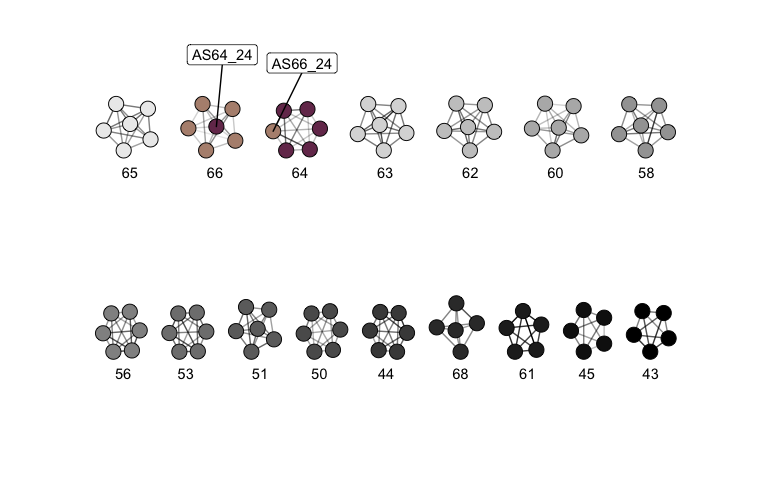

```r
selection <- samples.metadata %>%
  filter(grepl(Study, pattern = 'LOUISS')) %>%
  pull(Name)

sstr_graph <- generate_graph(sstr_cooccurrence, selection, 3)

yy = -.6
c.col = get_palette(c('black','white'), 15)

plot <-
  ggraph(sstr_graph, layout = 'stress') +
  geom_edge_link(aes(filter = weight >= 3, alpha = weight)
                 ) +
  geom_node_point(shape = 21, col = 'black',size = 5,
                  aes(fill = str_remove(Case_Name, pattern = 'LOUISS_Case_')),
                  ) +
  geom_node_label(aes(label = Sample,
                    filter = name %in% c('LOUISS_AS66_24.pair', 'LOUISS_AS64_24.pair')),
                 repel = T, hjust = .25, vjust = -3) +

  scale_y_continuous(expand = c(0.6, 0.6)) +
  scale_x_reverse(expand = c(0.1, 0.1)) +
  theme_graph() +
  theme(legend.position = 'none',
        strip.background = element_blank(),
        panel.spacing.y = unit(0, 'cm'),
        strip.placement = 'inside',
        strip.text = element_blank()
        ) +
  guides(edge_alpha = F,
         fill = guide_legend(override.aes=list(shape=21), title = '',
                             nrow = 2)) +
  scale_edge_alpha_continuous(breaks = c(5, 10, 25, 50)) +
  scale_fill_manual(values = c(
    # 43
    c.col[1],
    # 44
    c.col[5],
    # 45
    c.col[2],
    # 50
    c.col[6],
    # 51
    c.col[7],
    # 53
    c.col[8],
    # 56
    c.col[9],
    # 58
    c.col[10],
    # 60
    c.col[11],
    # 61
    c.col[3],
    # 62
    c.col[12],
    # 63
    c.col[13],
    # 64
    colors.discrete[4],
    # 65
    c.col[14],
    # 66
    '#B4907E',
    # 68
    c.col[4]
  )) +

  annotate('text', x = .6, y = yy, label = '43') +
  annotate('text', x = 2.75, y = yy, label = '45') +
  annotate('text', x = 4.75, y = yy, label = '61') +
  annotate('text', x = 7, y = yy, label = '68') +
  annotate('text', x = 9.5, y = yy, label = '44') +
  annotate('text', x = 11.75, y = yy, label = '50') +
  annotate('text', x = 13.75, y = yy, label = '51') +
  annotate('text', x = 16.25, y = yy, label = '53') +
  annotate('text', x = 18.35, y = yy, label = '56') +

  annotate('text', x = 20.6, y = yy, label = '58') +
  annotate('text', x = 23, y = yy, label = '60') +
  annotate('text', x = 25.25, y = yy, label = '62') +
  annotate('text', x = 27.5, y = yy, label = '63') +
  annotate('text', x = 29.75, y = yy, label = '64') +
  annotate('text', x = 32, y = yy, label = '66') +
  annotate('text', x = 34.25, y = yy, label = '65') +

  facet_wrap(~ x < 20, scales = 'free', nrow = 2)
plot
```

Exporting plot

```r
output_name = 'Mislabelling.Example1'

ggsave(plot,
       device = 'pdf', dpi = 300, width = 8, height = 5,
       filename = paste0(results_dir, fig, output_name, '.Plot.pdf'))
misl1 %>%
  write_tsv(., paste0(results_dir, fig, output_name, '.tsv'))
```

## ALM

ALM patient sample with many Donor strains BEFORE FMT labelled as recipient / pre-FMT Collected on day of FMT - As per C. Smillie not clear if before or after from notes

```r
selection <- samples.metadata %>%
  filter(Donor.Subject == 'D0_ALM_Case_4;5;6;8;9;12;13;15;17;18;20;21') %>%
  pull(Name)


samples.metadata.orig <-
  samples.metadata %>%
  select(Name, Case_Name, Sample_Type) %>%
  mutate(Sample_Type = ifelse(Name == 'ALM_FMT15.pair', 'recipient', Sample_Type))

misl2 <-
  get_matrix(sstr_cooccurrence, selection, 0) %>%
  rownames_to_column('row') %>%
  pivot_longer(names_to = 'col', values_to = 'shared',
               cols = ends_with('.pair')) %>%
  filter(row != col) %>%

  left_join(., samples.metadata.orig, by = c('row' = 'Name')) %>%
  left_join(., samples.metadata.orig, by = c('col' = 'Name'),
            suffix = c('.row','.col')) %>%

  filter(Sample_Type.row == 'recipient', Sample_Type.col != 'recipient') %>%
  mutate(Same = case_when(
    Sample_Type.col == 'post' & Case_Name.col == Case_Name.row ~ 'Self Post-FMT',
    Sample_Type.col == 'post' & Case_Name.col != Case_Name.row ~ 'Other Post-FMT',
    Sample_Type.col == 'donor' ~ 'Donor',
  )) %>%

  mutate(Recipient = str_remove(row, pattern = '.pair'),
         Study = 'ALM') %>%
  rename(Case_Name = 'Case_Name.row') %>%
  select(Study, Case_Name, Recipient, shared, Same) %>%
  group_by(Study, Case_Name, Recipient, Same) %>%
  summarize_all(.funs = funs(mean, sd)) %>%

  pivot_wider(names_from = 'Same', names_sep = '.',
              values_from = c('mean','sd')) %>%
  select(Study, Case_Name, Recipient, contains('Self'), contains('Other'), everything()) %>%

  mutate_at(.vars = vars(starts_with('mean'), starts_with('sd')),
            .funs = funs(replace_na(round(., 2), 0))) %>%
  mutate_at(.vars = vars(Case_Name, Recipient),
            .funs = funs(str_remove(., 'ALM_'))) %>%
  arrange(Recipient)
```

Denoising below 3 shared strains, showing all connections >4 strains

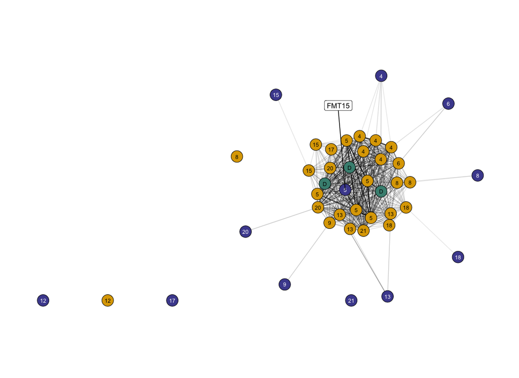

```r
selection <- samples.metadata %>%
  filter(Donor.Subject == 'D0_ALM_Case_4;5;6;8;9;12;13;15;17;18;20;21') %>%
  pull(Name)

sstr_graph <- generate_graph(sstr_cooccurrence, selection, 3)

plot <-
  ggraph(sstr_graph, layout = 'stress') +
  geom_edge_link(aes(filter = weight >= 5, alpha = weight)) +
  geom_node_point(shape = 21, col = 'black',size = 8,
                  aes(fill = case_when(
                    Days_Since_FMT == 0.5 ~ 'Recipient',
                    Sample_Type == 'post' ~ 'Post-FMT',
                    Sample_Type == 'donor' ~ 'Donor',
                    Sample_Type == 'recipient' ~ 'Recipient',
                    T ~ '?'
                  ))) +
  geom_node_text(size = 3,
                  aes(label = ifelse(Sample_Type == 'donor', 'D', Case_Number),
                      col = ifelse(Sample_Type == 'recipient' | name == 'ALM_FMT15.pair', 'R', 'DP')),
                  ) +
  geom_node_label(aes(label = Sample,
                    filter = name %in% c('ALM_FMT15.pair')),
                 repel = T, hjust = .75, vjust = -8) +
  scale_y_continuous(expand = c(0.25, 0)) +
  theme_graph(base_family = 'Helvetica') +
  # theme(legend.key.width = unit(1, 'cm'),
        # legend.key.height = unit(0.5, 'cm')) +
  scale_fill_manual(values = colors.discrete[c(1,2,3)]) +
  scale_edge_alpha_continuous(breaks = c(5, 10, 25, 50)) +
  scale_color_manual(values = c('black', 'white')) +
  guides(edge_alpha = guide_legend(title = 'Shared\nStrains',
                                   override.aes = list(size = 5)),
         col = F,
         fill = F)
plot + theme(legend.position = 'none')
```

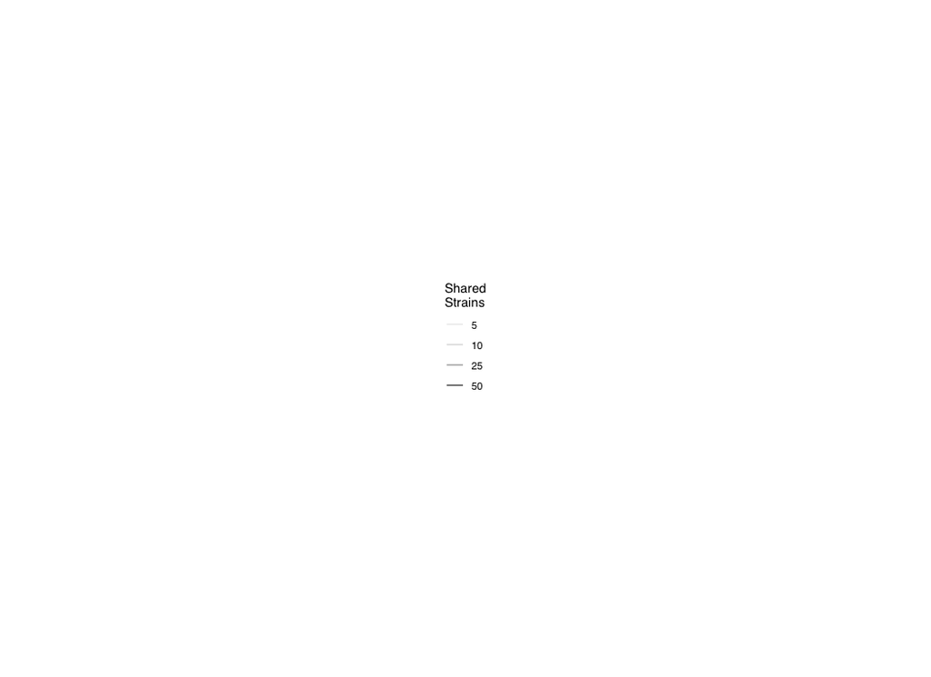

```r
legend = cowplot::get_legend(plot)
grid.newpage()
grid.draw(legend)
```

Exporting plot

```r
output_name = 'Mislabelling.Example2'

ggsave(plot + theme(legend.position = 'none'),
       device = 'pdf', dpi = 300, width = 11, height = 8,
       filename = paste0(results_dir, fig, output_name, '.Plot.pdf'))
ggsave(legend,
       device = 'pdf', dpi = 300, width = 1, height = 1.5,
       filename = paste0(results_dir, fig, output_name, '.Legend.pdf'))

misl2 %>%
  write_tsv(., paste0(results_dir, fig, output_name, '.tsv'))
```

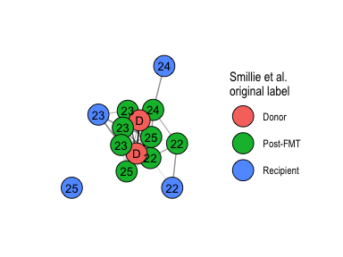

```r
selection <- samples.metadata %>%
  filter(Donor.Subject == 'D0_ALM_Case_22;23;24;25') %>%
  pull(Name)

sstr_graph <- generate_graph(sstr_cooccurrence, selection, 3)

ggraph(sstr_graph, layout = 'stress') +
  geom_edge_link(aes(filter = weight >= 3, alpha = weight)) +
  geom_node_point(shape = 21, col = 'black',size = 8,
                  aes(fill = case_when(
                    Days_Since_FMT == 0.5 ~ 'Recipient',
                    Sample_Type == 'post' ~ 'Post-FMT',
                    Sample_Type == 'donor' ~ 'Donor',
                    Sample_Type == 'recipient' ~ 'Recipient',
                    T ~ '?'
                  ))) +
  geom_node_text(col = 'black',size = 3.5,
                  aes(label = ifelse(Sample_Type == 'donor', 'D', Case_Number))
                  ) +
  geom_node_label(aes(label = Sample,
                    filter = name %in% c('ALM_FMT15.pair')),
                 repel = T, hjust = .75, vjust = -3) +
  scale_y_continuous(expand = c(0.25, 0)) +
  scale_x_continuous(expand = c(0.25, 0.25)) +

  theme_graph() +
  guides(edge_alpha = F,
         fill = guide_legend(override.aes = list(shape=21),
                             title = 'Smillie et al.\noriginal label', ncol = 1))
```

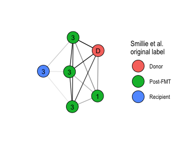

```r
selection <- samples.metadata %>%
  filter(Donor.Subject == 'D0_ALM_Case_1;3') %>%
  pull(Name)

sstr_graph <- generate_graph(sstr_cooccurrence, selection, 3)

ggraph(sstr_graph, layout = 'stress') +
  geom_edge_link(aes(filter = weight >= 3, alpha = weight)) +
  geom_node_point(shape = 21, col = 'black',size = 8,
                  aes(fill = case_when(
                    Days_Since_FMT == 0.5 ~ 'Recipient',
                    Sample_Type == 'post' ~ 'Post-FMT',
                    Sample_Type == 'donor' ~ 'Donor',
                    Sample_Type == 'recipient' ~ 'Recipient',
                    T ~ '?'
                  ))) +
  geom_node_text(col = 'black',size = 3.5,
                  aes(label = ifelse(Sample_Type == 'donor', 'D', Case_Number))
                  ) +
  geom_node_label(aes(label = Sample,
                    filter = name %in% c('ALM_FMT15.pair')),
                 repel = T, hjust = .75, vjust = -5) +
  scale_y_continuous(expand = c(0.25, 0)) +
  scale_x_continuous(expand = c(0.25, 0.25)) +
  theme_graph() +
  guides(edge_alpha = F,
         fill = guide_legend(override.aes = list(shape=21),
                             title = 'Smillie et al.\noriginal label', ncol = 1))
```

## FRICKE

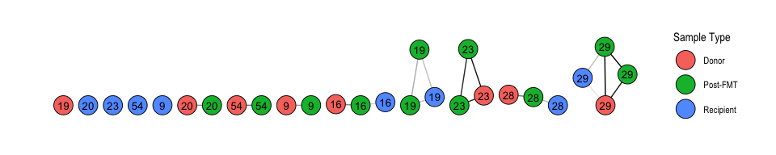

```r
selection <- samples.metadata %>%
  filter(Study == 'FRICKE') %>%
  pull(Name)

sstr_graph <- generate_graph(sstr_cooccurrence, selection, 3)

ggraph(sstr_graph, layout = 'stress') +
  geom_edge_link(aes(filter = weight >= 3, alpha = weight)) +
  geom_node_point(shape = 21, col = 'black',size = 8,
                  aes(fill = case_when(
                    Days_Since_FMT == 0.5 ~ 'Recipient',
                    Sample_Type == 'post' ~ 'Post-FMT',
                    Sample_Type == 'donor' ~ 'Donor',
                    Sample_Type == 'recipient' ~ 'Recipient',
                    T ~ '?'
                  ))) +
  geom_node_text(col = 'black',size = 3.5,
                  aes(label = Case_Number)
                  ) +
  geom_node_label(aes(label = Sample,
                    filter = name %in% c('ALM_FMT15.pair')),
                 repel = T, hjust = .75, vjust = -5) +
  scale_y_continuous(expand = c(0.25, 0)) +

  theme_graph() +
  guides(edge_alpha = F,
         fill = guide_legend(override.aes = list(shape=21),
                             title = 'Sample Type', ncol = 1))
```

## RAYMONDF

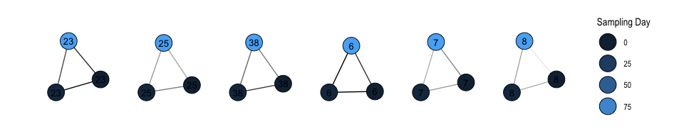

```r
selection <- samples.metadata %>%
  filter(Study == 'RAYMONDF') %>%
  pull(Name)

sstr_graph <- generate_graph(sstr_cooccurrence, selection, 3)

ggraph(sstr_graph, layout = 'stress') +
  geom_edge_link(aes(filter = weight >= 3, alpha = weight)) +
  geom_node_point(shape = 21, col = 'black',size = 8,
                  aes(fill = Days_Since_FMT)) +
  geom_node_text(col = 'black',size = 3.5,
                  aes(label = Case_Number)
                  ) +
  geom_node_label(aes(label = Sample,
                    filter = name %in% c('ALM_FMT15.pair')),
                 repel = T, hjust = .75, vjust = -5) +
  scale_y_continuous(expand = c(0.25, 0)) +

  theme_graph() +
  guides(edge_alpha = F,
         fill = guide_legend(override.aes = list(shape=21),
                             title = 'Sampling Day', ncol = 1))
```